# Project Python Foundations: FoodHub Data Analysis

**Marks: 60**

### Context

The number of restaurants in New York is increasing day by day. Lots of students and busy professionals rely on those restaurants due to their hectic lifestyles. Online food delivery service is a great option for them. It provides them with good food from their favorite restaurants. A food aggregator company FoodHub offers access to multiple restaurants through a single smartphone app.

The app allows the restaurants to receive a direct online order from a customer. The app assigns a delivery person from the company to pick up the order after it is confirmed by the restaurant. The delivery person then uses the map to reach the restaurant and waits for the food package. Once the food package is handed over to the delivery person, he/she confirms the pick-up in the app and travels to the customer's location to deliver the food. The delivery person confirms the drop-off in the app after delivering the food package to the customer. The customer can rate the order in the app. The food aggregator earns money by collecting a fixed margin of the delivery order from the restaurants.

### Objective

The food aggregator company has stored the data of the different orders made by the registered customers in their online portal. They want to analyze the data to get a fair idea about the demand of different restaurants which will help them in enhancing their customer experience. Suppose you are hired as a Data Scientist in this company and the Data Science team has shared some of the key questions that need to be answered. Perform the data analysis to find answers to these questions that will help the company to improve the business.

### Data Description

The data contains the different data related to a food order. The detailed data dictionary is given below.

### Data Dictionary

- order_id: Unique ID of the order
- customer_id: ID of the customer who ordered the food
- restaurant_name: Name of the restaurant
- cuisine_type: Cuisine ordered by the customer
- cost: Cost of the order
- day_of_the_week: Indicates whether the order is placed on a weekday or weekend (The weekday is from Monday to Friday and the weekend is Saturday and Sunday)
- rating: Rating given by the customer out of 5
- food_preparation_time: Time (in minutes) taken by the restaurant to prepare the food. This is calculated by taking the difference between the timestamps of the restaurant's order confirmation and the delivery person's pick-up confirmation.
- delivery_time: Time (in minutes) taken by the delivery person to deliver the food package. This is calculated by taking the difference between the timestamps of the delivery person's pick-up confirmation and drop-off information

### Let us start by importing the required libraries

```python
# import libraries for data manipulation
import numpy as np
import pandas as pd

# import libraries for data visualization
import matplotlib.pyplot as plt
import seaborn as sns
```

### Understanding the structure of the data

```python
# from google.colab import drive
# drive.mount('/content/drive')
```

```python
# read the data
df = pd.read_csv(r"C:\Users\james.awojobi\Downloads\foodhub_order.csv")
# returns the first 5 rows
df.head()
```

|  | order_id | customer_id | restaurant_name | cuisine_type | cost_of_the_order | day_of_the_week | rating | food_preparation_time | delivery_time |
| --- | --- | --- | --- | --- | --- | --- | --- | --- | --- |
| 0 | 1477147 | 337525 | Hangawi | Korean | 30.75 | Weekend | Not given | 25 | 20 |
| 1 | 1477685 | 358141 | Blue Ribbon Sushi Izakaya | Japanese | 12.08 | Weekend | Not given | 25 | 23 |
| 2 | 1477070 | 66393 | Cafe Habana | Mexican | 12.23 | Weekday | 5 | 23 | 28 |
| 3 | 1477334 | 106968 | Blue Ribbon Fried Chicken | American | 29.20 | Weekend | 3 | 25 | 15 |
| 4 | 1478249 | 76942 | Dirty Bird to Go | American | 11.59 | Weekday | 4 | 25 | 24 |

#### Observations:

The DataFrame has 9 columns as mentioned in the Data Dictionary. Data in each row corresponds to the order placed by a customer.

### **Question 1:** How many rows and columns are present in the data? [0.5 mark]

```python
df.shape
```

```
(1898, 9)
```

#### Observations:

There are **9 columns in the dataframe and 1898 rows. The 9 columns describes the 1898 observations present in the data

### **Question 2:** What are the datatypes of the different columns in the dataset? (The info() function can be used) [0.5 mark]

```python
df.info()
```

```
<class 'pandas.core.frame.DataFrame'>
RangeIndex: 1898 entries, 0 to 1897
Data columns (total 9 columns):
 #   Column                 Non-Null Count  Dtype
---  ------                 --------------  -----
 0   order_id               1898 non-null   int64
 1   customer_id            1898 non-null   int64
 2   restaurant_name        1898 non-null   object
 3   cuisine_type           1898 non-null   object
 4   cost_of_the_order      1898 non-null   float64
 5   day_of_the_week        1898 non-null   object
 6   rating                 1898 non-null   object
 7   food_preparation_time  1898 non-null   int64
 8   delivery_time          1898 non-null   int64
dtypes: float64(1), int64(4), object(4)
memory usage: 133.6+ KB
```

#### Observations:

There are three (3) data types in the dataset

**float64 *****(this data type is applicable to only 1 column of the dataset) which refers to the **column for cost_of_the_order

**int64 *****(this data type is applicable to 4 columns of the dataset) which refers to the following columns: **order_id, customer_id, food_preparation_time, and delivery_time

**object *****(this data type is applicable to 4 columns of the dataset) which refers to the following columns: **restaurant_name, cuisine_type, day_of_the_week, and rating

```python
for col in ["restaurant_name","cuisine_type", "day_of_the_week"]:
    df[col] = df[col].astype("category")
```

```python
df.info()
```

```
<class 'pandas.core.frame.DataFrame'>
RangeIndex: 1898 entries, 0 to 1897
Data columns (total 9 columns):
 #   Column                 Non-Null Count  Dtype
---  ------                 --------------  -----
 0   order_id               1898 non-null   int64
 1   customer_id            1898 non-null   int64
 2   restaurant_name        1898 non-null   category
 3   cuisine_type           1898 non-null   category
 4   cost_of_the_order      1898 non-null   float64
 5   day_of_the_week        1898 non-null   category
 6   rating                 1898 non-null   object
 7   food_preparation_time  1898 non-null   int64
 8   delivery_time          1898 non-null   int64
dtypes: category(3), float64(1), int64(4), object(1)
memory usage: 102.7+ KB
```

#### Observations:

A further analysis was done to convert the "objects" to "category". It is observed that there are still 1898 entries and 9 columns in the dataframe.

A note of difference is now seen. There are now four (4)data type as against the three earlier mentioned. The data types are:

**categorical *****(this data type is applicable to 3 columns of the dataset) which refers to the **restaurant_name, cuisine_type, and day_of_the_week**

**float64 *****(this data type is applicable to only 1 column of the dataset) which refers to the **column for cost_of_the_order**

**int64 *****(this data type is applicable to 4 columns of the dataset) which refers to the following columns: **order_id, customer_id, food_preparation_time, and delivery_time**

After the conversion of objects to category, **the memory usage reduced from 133.6+ KB to 102.7+ KB**

### **Question 3:** Are there any missing values in the data? If yes, treat them using an appropriate method. [1 mark]

```python
df.isnull().sum()
```

```
order_id                 0
customer_id              0
restaurant_name          0
cuisine_type             0
cost_of_the_order        0
day_of_the_week          0
rating                   0
food_preparation_time    0
delivery_time            0
dtype: int64
```

#### Observations:

There are **no missing values in the data**

### **Question 4:** Check the statistical summary of the data. What is the minimum, average, and maximum time it takes for food to be prepared once an order is placed? [2 marks]

```python
df.describe().T
```

|  | count | mean | std | min | 25% | 50% | 75% | max |
| --- | --- | --- | --- | --- | --- | --- | --- | --- |
| order_id | 1898.0 | 1.477496e+06 | 548.049724 | 1476547.00 | 1477021.25 | 1477495.50 | 1.477970e+06 | 1478444.00 |
| customer_id | 1898.0 | 1.711685e+05 | 113698.139743 | 1311.00 | 77787.75 | 128600.00 | 2.705250e+05 | 405334.00 |
| cost_of_the_order | 1898.0 | 1.649885e+01 | 7.483812 | 4.47 | 12.08 | 14.14 | 2.229750e+01 | 35.41 |
| food_preparation_time | 1898.0 | 2.737197e+01 | 4.632481 | 20.00 | 23.00 | 27.00 | 3.100000e+01 | 35.00 |
| delivery_time | 1898.0 | 2.416175e+01 | 4.972637 | 15.00 | 20.00 | 25.00 | 2.800000e+01 | 33.00 |

#### Observations:

From the statistical summary of the data, it takes a **minimum of 20 minutes for food to be prepared after an order is placed *****(which is claculated from restaurant's order confirmation and the delivery person's pick-up confirmation.

The **average time required for food to be prepared after an order is placed according to the data is 27 minutes**

The **maximum time required for food to be prepared after an order is placed according to the data is 35 minutes**

### **Question 5:** How many orders are not rated? [1 mark]

```python
df.rating.unique()
```

```
array(['Not given', '5', '3', '4'], dtype=object)
```

```python
df["rating"].value_counts()
```

```
Not given    736
5            588
4            386
3            188
Name: rating, dtype: int64
```

#### Observations:

The data shows that there are **736(Seven Hundred and Thirty-Six) orders that are not rated**

### Exploratory Data Analysis (EDA)

### **Question 6:** Explore all the variables and provide observations on their distributions. (Generally, histograms, boxplots, countplots, etc. are used for univariate exploration.) [9 marks]

## Order ID

```python
df.order_id.nunique()
```

```
1898
```

#### Observations:

There are 1898 unique values of the order ID. This implies that there are a total of 1898 orders in the dataset

## Customer ID

```python
df.customer_id.nunique()
```

```
1200
```

```python
df.customer_id.value_counts().unique()
```

```
array([13, 10,  9,  8,  7,  6,  5,  4,  3,  2,  1], dtype=int64)
```

```python
df.duplicated("customer_id").sum()
```

```
698
```

```python
df.drop_duplicates("customer_id")
df.shape
```

```
(1898, 9)
```

#### Observations:

Out of the 1898 observations provided in the dataset, **FoodHub has a total of 1200 unique customers registered on its online portal.** 698 are duplicated customer IDs

## Restaurant Name

```python
df = pd.read_csv(r"C:\Users\james.awojobi\Downloads\foodhub_order.csv")
df.restaurant_name.nunique()
```

```
178
```

```python
df.restaurant_name.value_counts().head(10)
```

```
Shake Shack                      219
The Meatball Shop                132
Blue Ribbon Sushi                119
Blue Ribbon Fried Chicken         96
Parm                              68
RedFarm Broadway                  59
RedFarm Hudson                    55
TAO                               49
Han Dynasty                       46
Blue Ribbon Sushi Bar & Grill     44
Name: restaurant_name, dtype: int64
```

#### Observations:

There are **178 restaurants and Shake Shack is the top restaurant with over 200 orders placed**

## Cuisine type

```python
df.cuisine_type.nunique()
```

```
14
```

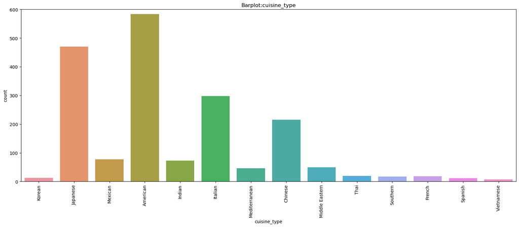

```python
plt.figure(figsize = (20,7))
plt.title("Barplot:cuisine_type")
plt.ylim(0,600)
sns.countplot(data=df, x="cuisine_type")
plt.xticks(rotation=90)
plt.show()
```

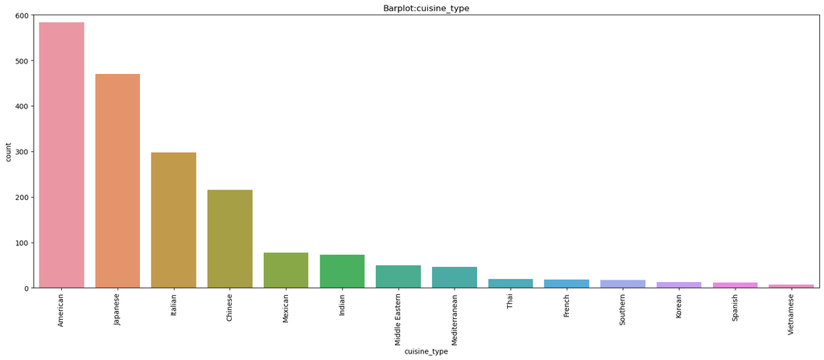

```python
plt.figure(figsize = (20,7))
plt.title("Barplot:cuisine_type")
plt.ylim(0,600)
sns.countplot(data=df, x="cuisine_type", order=df.cuisine_type.value_counts().iloc[:14].index)
plt.xticks(rotation=90)
plt.show()
```

```python
df.cuisine_type.value_counts()
```

```
American          584
Japanese          470
Italian           298
Chinese           215
Mexican            77
Indian             73
Middle Eastern     49
Mediterranean      46
Thai               19
French             18
Southern           17
Korean             13
Spanish            12
Vietnamese          7
Name: cuisine_type, dtype: int64
```

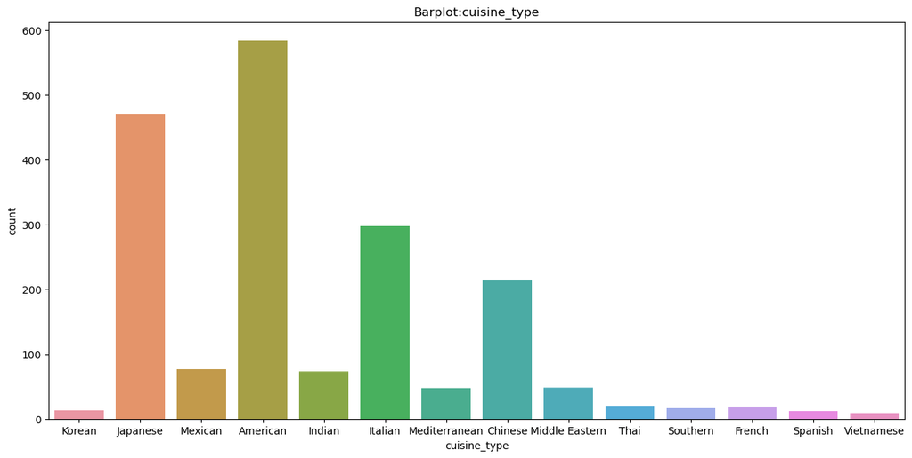

```python
plt.figure(figsize = (15,7))
plt.title("Barplot:cuisine_type")
sns.countplot(data=df, x= "cuisine_type");
```

#### Observations:

There are a total of **14 cuisine type**. The **American cuisine is mostly ordered, accounting for over 500 placed orders followed by Japanese, Italian, Chinese and Mexican to complete the top 5**

## Cost of the order

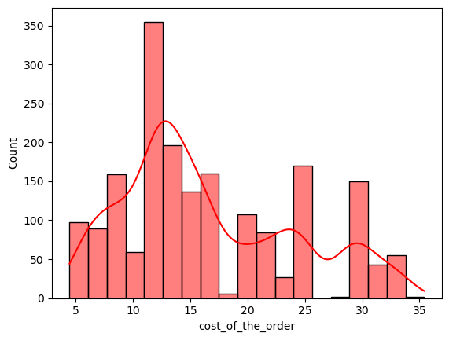

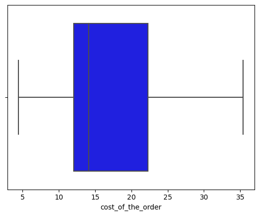

```python
sns.histplot(data=df, x="cost_of_the_order", color="Red", kde=True)
plt.show()
sns.boxplot(data=df, x="cost_of_the_order", color="Blue")
plt.show()
```

#### Observations:

The histogram and boxplot shows that cost_of_the_order is **skewed to the right giving it an asymmetric distribution from the kde view.**

## Day of the week

```python
df.day_of_the_week.value_counts(normalize=True)
```

```
Weekend    0.711802
Weekday    0.288198
Name: day_of_the_week, dtype: float64
```

```python
df.day_of_the_week.value_counts()
```

```
Weekend    1351
Weekday     547
Name: day_of_the_week, dtype: int64
```

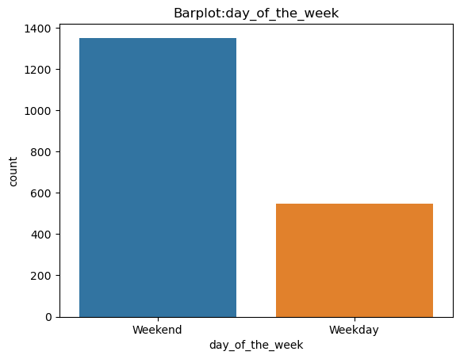

```python
plt.title("Barplot:day_of_the_week")
sns.countplot(data=df, x="day_of_the_week");
```

#### Observations:

It is interesting to note that most of the orders placed on FoodHub are done on **weekends. 1351 orders, representing 71% are placed on weekends while 29% (547 orders) are placed on weekdays

## Rating

```python
df.rating.nunique()
```

```
4
```

```python
df.rating.value_counts(normalize=True)
```

```
Not given    0.387777
5            0.309800
4            0.203372
3            0.099052
Name: rating, dtype: float64
```

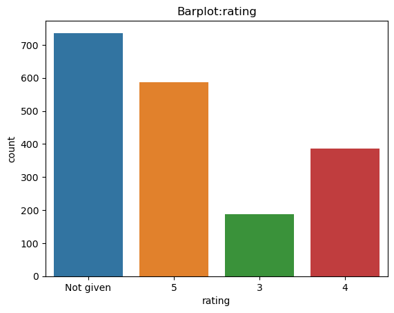

```python
plt.title("Barplot:rating")
sns.countplot(data=df, x="rating");
```

## Food Preparation Time

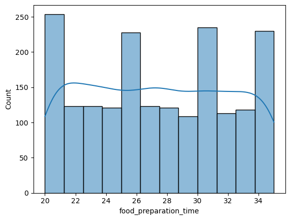

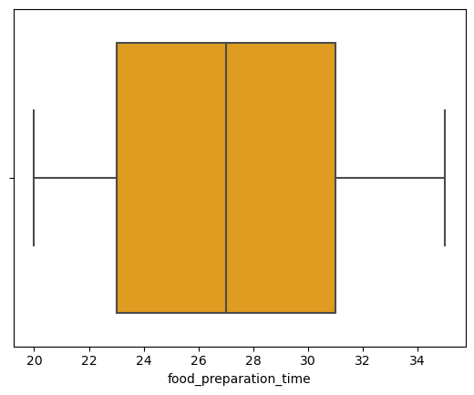

```python
sns.histplot(data=df, x="food_preparation_time", kde=True, linewidth=1)
plt.show()
sns.boxplot(data=df, x="food_preparation_time", color="Orange")
plt.show()
```

## Delivery time

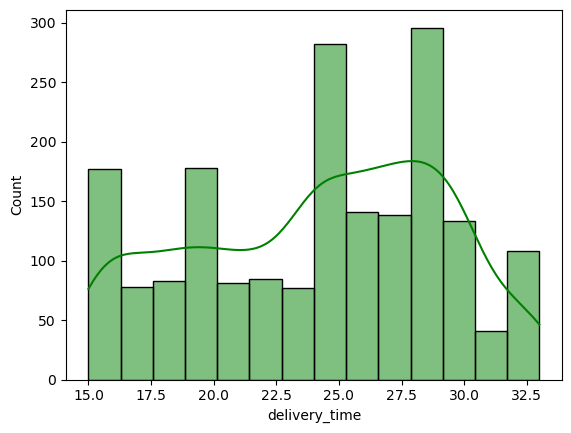

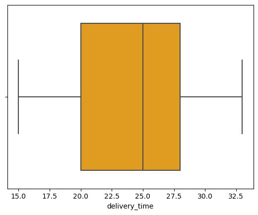

```python
sns.histplot(data=df, x="delivery_time", kde=True, color="Green")
plt.show()
sns.boxplot(data=df, x="delivery_time", color="Orange")
plt.show()
```

#### Observations

The delivery_time is **left skewed. The fastest delivery time is 15 minutes and the longest is 33 minutes. Delivery_time for orders on FoodHub takes an average of 24 minutes**

### **Question 7**: Which are the top 5 restaurants in terms of the number of orders received? [1 mark]

```python
df["restaurant_name"].value_counts().head(5)
```

```
Shake Shack                  219
The Meatball Shop            132
Blue Ribbon Sushi            119
Blue Ribbon Fried Chicken     96
Parm                          68
Name: restaurant_name, dtype: int64
```

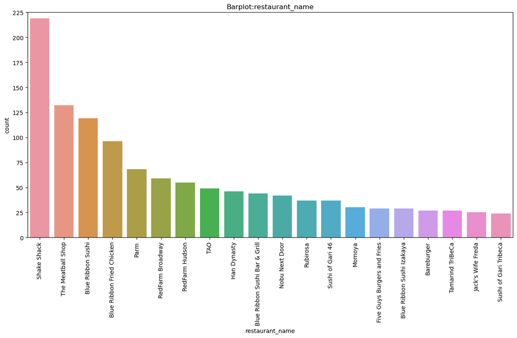

```python
plt.figure(figsize = (15,7))
plt.title("Barplot:restaurant_name")
plt.ylim(0,225)
sns.countplot(data=df, x="restaurant_name", order=df.restaurant_name.value_counts().iloc[:20].index)
plt.xticks(rotation=90);
```

#### Observations:

The top 5 restaurants in terms of the number of orders received are:

1st - Shake Shack  
2nd - The Meatball Shop  
3rd - Blue Ribbon Sushi  
4th - Blue Ribbon Fried Chicken  
5th - Parm

### **Question 8**: Which is the most popular cuisine on weekends? [1 mark]

```python
df.groupby(["day_of_the_week"])["cuisine_type"].value_counts()
```

```
day_of_the_week  cuisine_type
Weekday          American          169
                 Japanese          135
                 Italian            91
                 Chinese            52
                 Indian             24
                 Mexican            24
                 Middle Eastern     17
                 Mediterranean      14
                 Southern            6
                 French              5
                 Thai                4
                 Vietnamese          3
                 Korean              2
                 Spanish             1
Weekend          American          415
                 Japanese          335
                 Italian           207
                 Chinese           163
                 Mexican            53
                 Indian             49
                 Mediterranean      32
                 Middle Eastern     32
                 Thai               15
                 French             13
                 Korean             11
                 Southern           11
                 Spanish            11
                 Vietnamese          4
Name: cuisine_type, dtype: int64
```

#### Observations:

The **American cuisine** is the most popular on weekends.

### **Question 9**: What percentage of the orders cost more than 20 dollars? [2 marks]

```python
df_above_20USD = df[df["cost_of_the_order"]>20]
print("The number of total orders that cost more than 20 dollars is:", df_above_20USD.shape[0])
percentage = df_above_20USD.shape[0]/df.shape[0]*100
print("The percentage of orders that cost more than 20 dollars is:", round(percentage, 2), "%")
```

```
The number of total orders that cost more than 20 dollars is: 555
The percentage of orders that cost more than 20 dollars is: 29.24 %
```

#### Observations:

**29.24% of all orders in the dataset cost more than 20 dollars**

### **Question 10**: What is the mean order delivery time? [1 mark]

```python
df["delivery_time"].mean()
```

```
24.161749209694417
```

#### Observations:

It takes an **average of approximately 24 minutes** for a placed order to be delivered

### **Question 11:** The company has decided to give 20% discount vouchers to the top 3 most frequent customers. Find the IDs of these customers and the number of orders they placed. [1 mark]

```python
df.customer_id.value_counts().head(5)
```

```
52832     13
47440     10
83287      9
250494     8
259341     7
Name: customer_id, dtype: int64
```

#### Observations:

The top 3 most frequent customers using their ID:

**Customer_id 52832 with 13 orders** **Customer_id 47440 with 10 orders** **Customer_id 83287 with 9 orders**

### **Question 12**: Perform a multivariate analysis to explore relationships between the important variables in the dataset. (It is a good idea to explore relations between numerical variables as well as relations between numerical and categorical variables) [10 marks]

## Correlation of Variables

```python
df.corr()
```

|  | order_id | customer_id | cost_of_the_order | food_preparation_time | delivery_time |
| --- | --- | --- | --- | --- | --- |
| order_id | 1.000000 | -0.013960 | 0.021171 | -0.007026 | 0.009690 |
| customer_id | -0.013960 | 1.000000 | -0.001322 | -0.030330 | -0.009885 |
| cost_of_the_order | 0.021171 | -0.001322 | 1.000000 | 0.041527 | -0.029949 |
| food_preparation_time | -0.007026 | -0.030330 | 0.041527 | 1.000000 | 0.011094 |
| delivery_time | 0.009690 | -0.009885 | -0.029949 | 0.011094 | 1.000000 |

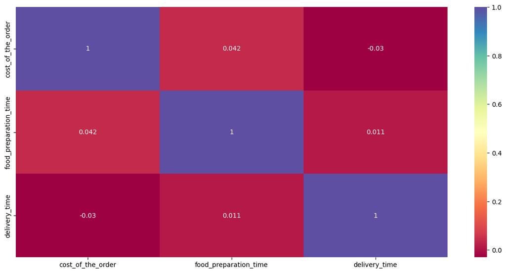

```python
plt.figure(figsize=(15,7))
sns.heatmap(data=df[['cost_of_the_order', 'food_preparation_time', 'delivery_time']].corr(), annot=True, cmap="Spectral")
plt.show()
```

#### Observations:

**There is no strong correlation among the variables**

## Cuisine vs Cost_of_the_order

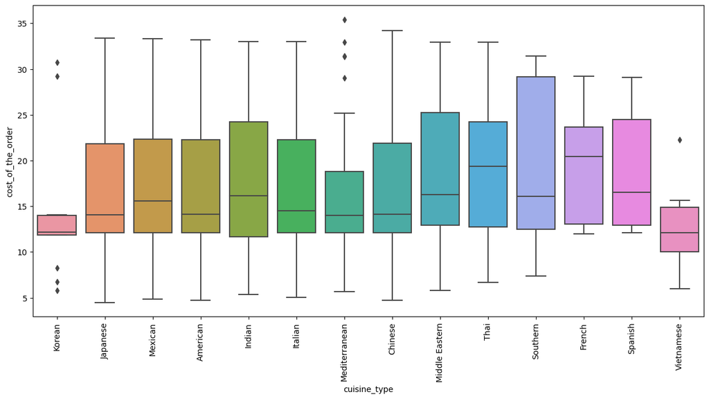

```python
plt.figure(figsize=(15,7))
sns.boxplot(data=df, x="cuisine_type", y="cost_of_the_order")
plt.xticks(rotation=90)
plt.show()
```

#### Observations:

**The Mediterranean cuisine shows an outlier of above 35USD in the cost of order placed**

## Cuisine vs Food_preparation_time

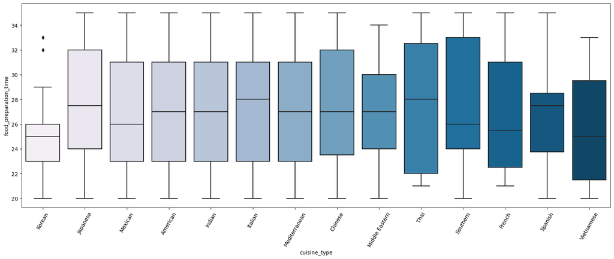

```python
plt.figure(figsize=(20,7))
sns.boxplot(data=df, x="cuisine_type", y="food_preparation_time", palette="PuBu")
plt.xticks(rotation=60)
plt.show()
```

## Day_of_the_week vs Delivery_time

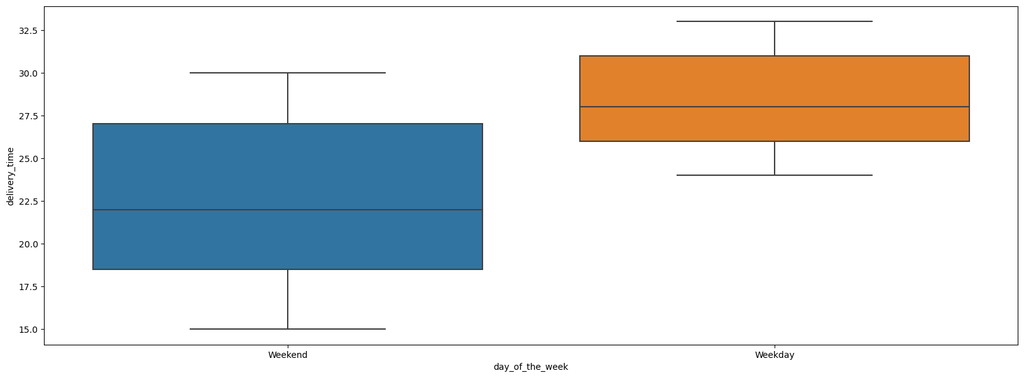

```python
plt.figure(figsize=(20,7))
sns.boxplot(data=df, x="day_of_the_week", y="delivery_time");
```

## Day_of_the_week vs Cost_of_the_order

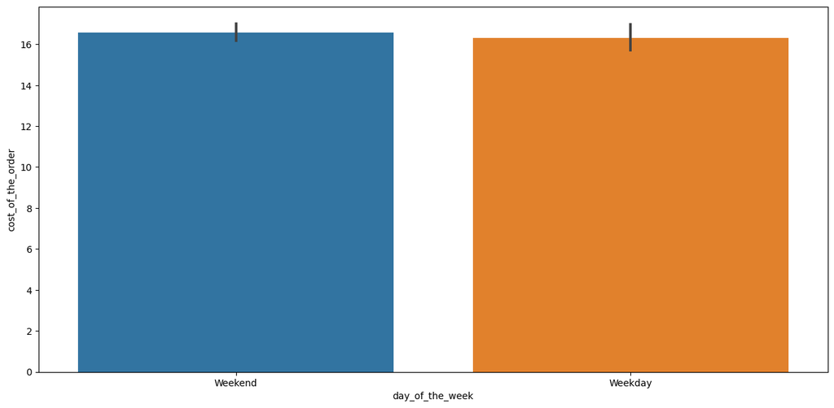

```python
plt.figure(figsize=(15,7))
sns.barplot(data=df, x="day_of_the_week", y="cost_of_the_order");
```

## Revenue generated by the restaurants

```python
df.groupby(["restaurant_name"])["cost_of_the_order"].sum().sort_values(ascending= False).head(14)
```

```
restaurant_name
Shake Shack                      3579.53
The Meatball Shop                2145.21
Blue Ribbon Sushi                1903.95
Blue Ribbon Fried Chicken        1662.29
Parm                             1112.76
RedFarm Broadway                  965.13
RedFarm Hudson                    921.21
TAO                               834.50
Han Dynasty                       755.29
Blue Ribbon Sushi Bar & Grill     666.62
Rubirosa                          660.45
Sushi of Gari 46                  640.87
Nobu Next Door                    623.67
Five Guys Burgers and Fries       506.47
Name: cost_of_the_order, dtype: float64
```

#### Observations:

**The Shake Shack generated the highest revenues followed by the Meatball Shop, Blue Ribbon Sushi, Blue Ribbon Fried Chicken and Parm as top 5 restaurants with high revenues above 1000USD. Other restaurants generate revenues below 1000USD**

## Rating vs Delivery_time

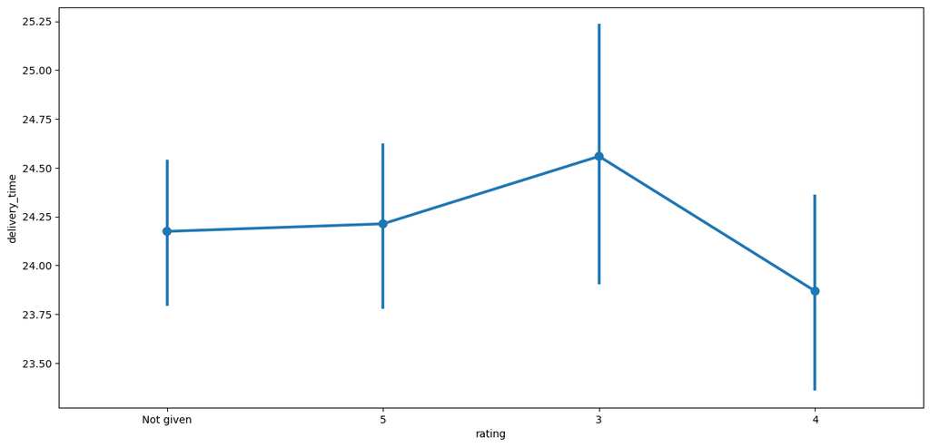

```python
plt.figure(figsize=(15,7))
sns.pointplot(data=df, x="rating", y="delivery_time")
plt.show()
```

## Rating vs Food_preparation_time

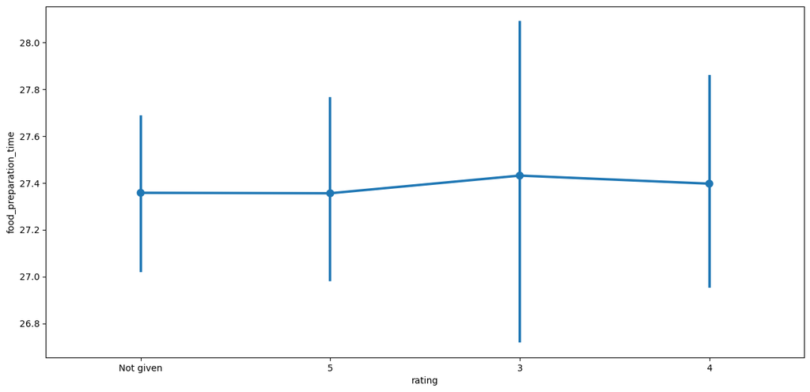

```python
plt.figure(figsize=(15,7))
sns.pointplot(data=df,x="rating", y="food_preparation_time" )
plt.show()
```

## Rating vs Cost_of_the_order

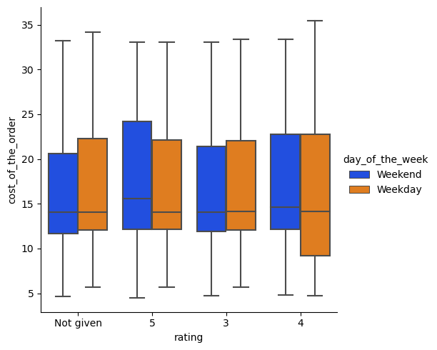

```python
sns.catplot(data=df, x="rating", y="cost_of_the_order", hue="day_of_the_week", kind="box", palette="bright")
plt.show()
```

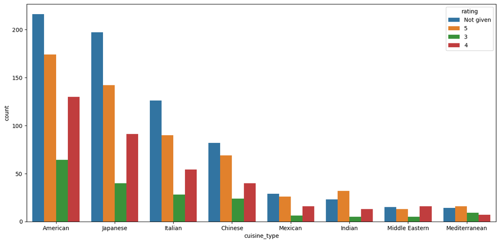

```python
plt.figure(figsize=(15,7))
sns.countplot(data=df, x="cuisine_type", hue="rating", order=df.cuisine_type.value_counts().iloc[:8].index);
```

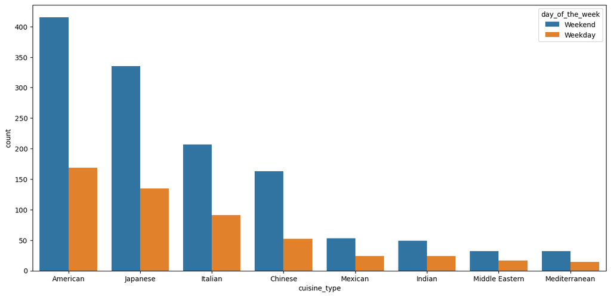

```python
plt.figure(figsize=(15,7))
sns.countplot(data=df, x="cuisine_type", hue="day_of_the_week", order=df.cuisine_type.value_counts().iloc[:8].index);
```

#### Observations:

**Day of the week does not affect the selection of cuisine type** **The top 5 cuisine_type on weekends are still the top 5 cuisine_type ordered on weekdays**

## Cost_of_the_order vs Delivery_time

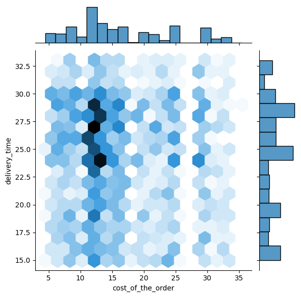

```python
sns.jointplot(data=df, x="cost_of_the_order", y="delivery_time", kind="hex");
```

#### Observations:

**Cost of the order is densely arranged around 11USD with delivery time range from 23 minutes to 29 minutes**

### **Question 13:** The company wants to provide a promotional offer in the advertisement of the restaurants. The condition to get the offer is that the restaurants must have a rating count of more than 50 and the average rating should be greater than 4. Find the restaurants fulfilling the criteria to get the promotional offer. [3 marks]

```python
df_rated = df[df["rating"]!="Not given"].copy()
```

```python
df_rated["rating"] = df_rated["rating"].astype("int")
```

```python
df_rating_count = df_rated.groupby(["restaurant_name"])["rating"].count().sort_values(ascending=False).reset_index()
df_rating_count.head()
```

|  | restaurant_name | rating |
| --- | --- | --- |
| 0 | Shake Shack | 133 |
| 1 | The Meatball Shop | 84 |
| 2 | Blue Ribbon Sushi | 73 |
| 3 | Blue Ribbon Fried Chicken | 64 |
| 4 | RedFarm Broadway | 41 |

```python
 df1 = df.drop(df.index[(df['rating'] != '3') & (df['rating'] != '4') & (df['rating'] != '5')])
df1
```

|  | order_id | customer_id | restaurant_name | cuisine_type | cost_of_the_order | day_of_the_week | rating | food_preparation_time | delivery_time |
| --- | --- | --- | --- | --- | --- | --- | --- | --- | --- |
| 2 | 1477070 | 66393 | Cafe Habana | Mexican | 12.23 | Weekday | 5 | 23 | 28 |
| 3 | 1477334 | 106968 | Blue Ribbon Fried Chicken | American | 29.20 | Weekend | 3 | 25 | 15 |
| 4 | 1478249 | 76942 | Dirty Bird to Go | American | 11.59 | Weekday | 4 | 25 | 24 |
| 5 | 1477224 | 147468 | Tamarind TriBeCa | Indian | 25.22 | Weekday | 3 | 20 | 24 |
| 7 | 1477859 | 89574 | Barbounia | Mediterranean | 5.97 | Weekday | 3 | 33 | 30 |
| ... | ... | ... | ... | ... | ... | ... | ... | ... | ... |
| 1889 | 1478190 | 94152 | RedFarm Broadway | Chinese | 8.68 | Weekday | 3 | 33 | 30 |
| 1890 | 1477316 | 164776 | TAO | Japanese | 15.67 | Weekend | 5 | 20 | 22 |
| 1893 | 1476701 | 292602 | Chipotle Mexican Grill $1.99 Delivery | Mexican | 22.31 | Weekend | 5 | 31 | 17 |
| 1894 | 1477421 | 397537 | The Smile | American | 12.18 | Weekend | 5 | 31 | 19 |
| 1896 | 1477513 | 64151 | Jack's Wife Freda | Mediterranean | 12.18 | Weekday | 5 | 23 | 31 |

1162 rows × 9 columns

```python
df1["restaurant_name"].value_counts() > 50
```

```
Shake Shack                     True
The Meatball Shop               True
Blue Ribbon Sushi               True
Blue Ribbon Fried Chicken       True
RedFarm Broadway               False
                               ...
Philippe Chow                  False
Dirty Bird To Go (archived)    False
The MasalaWala                 False
Kambi Ramen House              False
'wichcraft                     False
Name: restaurant_name, Length: 156, dtype: bool
```

```python
df2=df1.drop(df1.index[(df1["restaurant_name"] !="Shake Shack")
                       &(df1["restaurant_name"] !="Blue Ribbon Fried Chicken")
                       &(df1["restaurant_name"] !="The Meatball Shop")
                       &(df1["restaurant_name"] !="Blue Ribbon Sushi")])
```

```python
df2
```

|  | order_id | customer_id | restaurant_name | cuisine_type | cost_of_the_order | day_of_the_week | rating | food_preparation_time | delivery_time |
| --- | --- | --- | --- | --- | --- | --- | --- | --- | --- |
| 3 | 1477334 | 106968 | Blue Ribbon Fried Chicken | American | 29.20 | Weekend | 3 | 25 | 15 |
| 12 | 1476966 | 129969 | Blue Ribbon Fried Chicken | American | 24.30 | Weekend | 5 | 23 | 17 |
| 15 | 1477414 | 66222 | Shake Shack | American | 16.20 | Weekend | 5 | 33 | 25 |
| 19 | 1477354 | 67487 | Blue Ribbon Sushi | Japanese | 16.20 | Weekend | 4 | 35 | 26 |
| 22 | 1478287 | 150599 | Shake Shack | American | 29.10 | Weekday | 5 | 21 | 30 |
| ... | ... | ... | ... | ... | ... | ... | ... | ... | ... |
| 1880 | 1477466 | 222734 | Shake Shack | American | 13.97 | Weekend | 5 | 35 | 27 |
| 1884 | 1477437 | 304993 | Shake Shack | American | 31.43 | Weekend | 3 | 31 | 24 |
| 1885 | 1477550 | 97324 | Shake Shack | American | 29.05 | Weekday | 4 | 27 | 29 |
| 1886 | 1478277 | 48282 | The Meatball Shop | American | 14.50 | Weekend | 5 | 34 | 25 |
| 1888 | 1477353 | 106324 | The Meatball Shop | Italian | 16.20 | Weekend | 5 | 21 | 26 |

354 rows × 9 columns

```python
for col in ["rating"]:
    df2[col] = df2[col].astype("int")
```

```python
df2.groupby("restaurant_name")["rating"].mean().sort_values(ascending=False).head()
```

```
restaurant_name
The Meatball Shop            4.511905
Blue Ribbon Fried Chicken    4.328125
Shake Shack                  4.278195
Blue Ribbon Sushi            4.219178
Name: rating, dtype: float64
```

#### Observations:

From the dataset, only 4 of the 178 restaurants met the conditions to get a promotional offer in advertisements. These 4 restaurants have average ratings greater than 4 and all have more than a rating count of 50

The 4 restaurants are listed below:

The Meatball Shop Blue Ribbon Fried Chicken Shake Shack Blue Ribbon Sushi

**The Shake Shack has the highest rating count of 133 and the Meatball Shop has the highest average rating of 4.5**

### **Question 14:** The company charges the restaurant 25% on the orders having cost greater than 20 dollars and 15% on the orders having cost greater than 5 dollars. Find the net revenue generated by the company across all orders. [3 marks]

```python
sum=0
for i in df["cost_of_the_order"]:
    if (i > 20):
        sum = sum + (i*0.25)
    elif (5 < i <20):
        sum = sum + (i*0.15)
    else:
        sum = sum + (i*0)
print("The net revenue on all orders is:", "{:.2f}".format(sum))
```

```
The net revenue on all orders is: 6166.30
```

#### Observations:

**The net revenue generated by the Company across all orders is 6166.30**

### **Question 15:** The company wants to analyze the total time required to deliver the food. What percentage of orders take more than 60 minutes to get delivered from the time the order is placed? (The food has to be prepared and then delivered.) [2 marks]

```python
df["total_time"]=df["food_preparation_time"] + df["delivery_time"]
print("The total time required to deliver the food is:", df["total_time"])
```

```
The total time required to deliver the food is: 0       45
1       48
2       51
3       40
4       49
        ..
1893    48
1894    50
1895    55
1896    54
1897    52
Name: total_time, Length: 1898, dtype: int64
```

```python
percentage = (len(df[df["total_time"]>60]) / len(df))*100
print("Percentage:", round(percentage, 2), "%")
```

```
Percentage: 10.54 %
```

#### Observations:

**10.54% of orders take more than 60 minutes to get delivered from the time the order is placed**

### **Question 16:** The company wants to analyze the delivery time of the orders on weekdays and weekends. How does the mean delivery time vary during weekdays and weekends? [2 marks]

```python
df.groupby(["day_of_the_week"])["delivery_time"].mean()
```

```
day_of_the_week
Weekday    28.340037
Weekend    22.470022
Name: delivery_time, dtype: float64
```

#### Observations:

**The mean delivery time on weekdays is greater than weekends**

## Conclusion and Recommendations

### Recommendations:

- FoodHub should carefully analyze their operationsin the weekday. There is the need to carefully review the nature of weekday orders and consider targeted promotions to increase orders placed during weekdays. FoodHub needs to consider the delivery time of orders during weekdays factoring peak and off-peak traffic scenarios.
- FoodHub should consider carrying out root cause analysis on restauthat are experiencing low orders. There might be need to consider the food quality, cuisine type, packaging among other performance indicators
- FoodHub needs to support new restaurants or struggling restaurants by engaging targeted adverts and promotions
- FoodHub should introduce more incentives to encourage customers to rate the orders placed